# Project 2

Dayoung Han (01903952), Jaehyun koo (01715475), Seungchan Oh(01603277), Yewon Son (01507594)

2021 5 7

### **Statistical analyses**

**(a)**

> Perform an explanatory analysis on the data. Investigate the relation between the predictor variables and the outcome Weight, taking into account the different species encoded in Species.

In the data, it consists of 6 continous variables and 1 categorical variable. The data consist of 159 observations.

| Name | Characteristics | Type |
| --- | --- | --- |
| Species | name of the species | Categorical |
| Weight | weight of individual fish (in g) | Continuous |
| Length1 | vertical length of fish (in cm) | Continuous |
| Length2 | diagonal length of fish (in cm) | Continuous |
| Length3 | cross length of fish (in cm) | Continuous |
| Height | height of fish (in cm) | Continuous |
| Width | width of fish (in cm) | Continuous |

There is a zero value in the data of Weight. Values of Weight are only positive real number and in fact, it indicates an unknown value. Therefore, this observation should be excluded.

```r
print(fish[41,])
```

```
##    Species Weight Length1 Length2 Length3 Height  Width
## 41   Roach      0      19    20.5    22.8 6.4752 3.3516
```

```r
fish <- fish[-41,]
attach(fish)
print(fish$Weight)
```

```
##   [1]  242.0  290.0  340.0  363.0  430.0  450.0  500.0  390.0  450.0  500.0
##  [11]  475.0  500.0  500.0  340.0  600.0  600.0  700.0  700.0  610.0  650.0
##  [21]  575.0  685.0  620.0  680.0  700.0  725.0  720.0  714.0  850.0 1000.0
##  [31]  920.0  955.0  925.0  975.0  950.0   40.0   69.0   78.0   87.0  120.0
##  [41]  110.0  120.0  150.0  145.0  160.0  140.0  160.0  169.0  161.0  200.0
##  [51]  180.0  290.0  272.0  390.0  270.0  270.0  306.0  540.0  800.0 1000.0
##  [61]   55.0   60.0   90.0  120.0  150.0  140.0  170.0  145.0  200.0  273.0
##  [71]  300.0    5.9   32.0   40.0   51.5   70.0  100.0   78.0   80.0   85.0
##  [81]   85.0  110.0  115.0  125.0  130.0  120.0  120.0  130.0  135.0  110.0
##  [91]  130.0  150.0  145.0  150.0  170.0  225.0  145.0  188.0  180.0  197.0
## [101]  218.0  300.0  260.0  265.0  250.0  250.0  300.0  320.0  514.0  556.0
## [111]  840.0  685.0  700.0  700.0  690.0  900.0  650.0  820.0  850.0  900.0
## [121] 1015.0  820.0 1100.0 1000.0 1100.0 1000.0 1000.0  200.0  300.0  300.0
## [131]  300.0  430.0  345.0  456.0  510.0  540.0  500.0  567.0  770.0  950.0
## [141] 1250.0 1600.0 1550.0 1650.0    6.7    7.5    7.0    9.7    9.8    8.7
## [151]   10.0    9.9    9.8   12.2   13.4   12.2   19.7   19.9
```

To identify relation between outcome and each predictor, scatterplot should be drawn.

#### **Scatterplot**

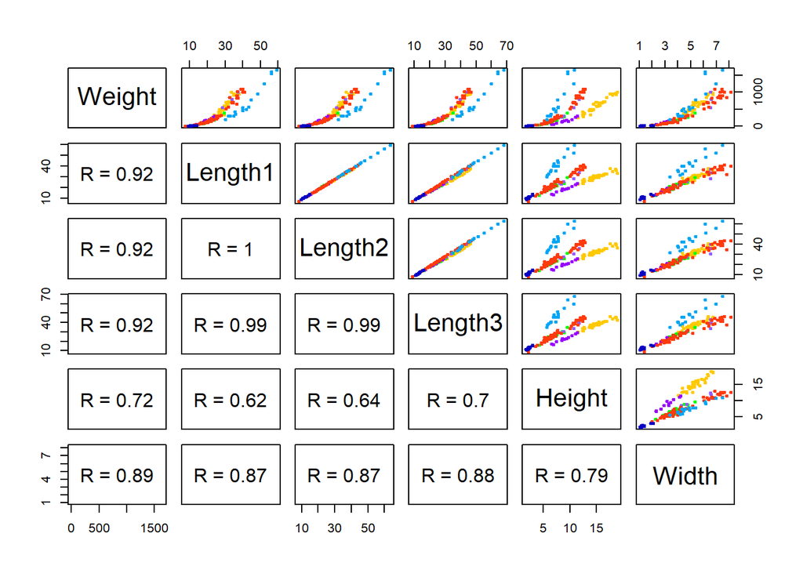

#### **Log transformation**

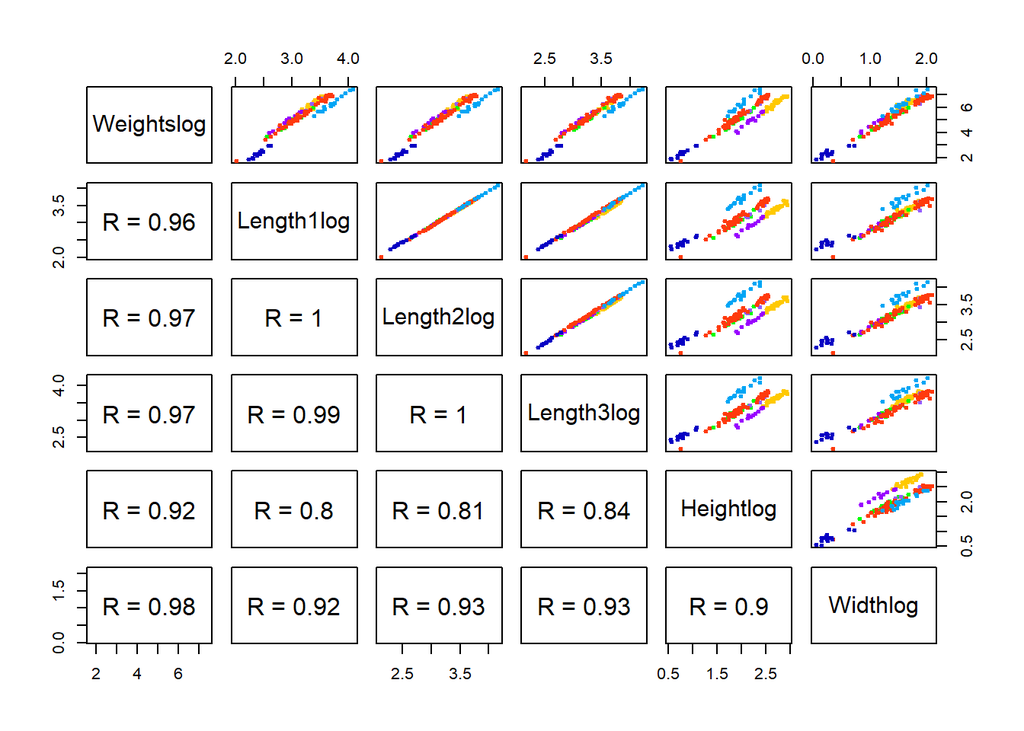

For outcome Weight, each of predictors have exponential relation. Therefore, it is better to transform Weight with log for linearity. Even though transformation of predictors will not affect on distribution of outcome for predictors, it is executed for better linearity. although the values of Weight are still as values of the predictors increase, linearity for each species on each predictors are still satisfied. Residuals derived from Species will be very much corrected by dummy variable of Species. In addition, note that multicollinearity among Length1, Length2, and Length3 is indicated.

**(b)**

> Build the optimal regression model (using forward model building) which describes the relationship between Weight and the other predictors. Consider Length1, Length2, Length3, Height and Width as candidates for the independent variables. There is no need to include quadratic or higher orders effect, but interaction terms can be considered.

From **(a)**, the independent variables (predictors) and dependent variable (Weight) showed linear relationship in logarithmic form. Hence, logarithmic form of each predictors are considered when building the model.

Candidates for the independent variables are:

- **Length1**
- **Length2**
- **Length3**
- **Height**
- **Width**

##### **1. Checking for the first term.**

###### **Model1**

```r
model1 <- lm(Weightslog ~ Length1log); summary(model1)
```

```
##
## Call:
## lm(formula = Weightslog ~ Length1log)
##
## Residuals:
##      Min       1Q   Median       3Q      Max
## -0.90870 -0.07280  0.07773  0.26639  0.50636
##
## Coefficients:
##             Estimate Std. Error t value Pr(>|t|)
## (Intercept) -4.62769    0.23481  -19.71   <2e-16 ***
## Length1log   3.14394    0.07296   43.09   <2e-16 ***
## ---
## Signif. codes:  0 '***' 0.001 '**' 0.01 '*' 0.05 '.' 0.1 ' ' 1
##
## Residual standard error: 0.3704 on 156 degrees of freedom
## Multiple R-squared:  0.9225, Adjusted R-squared:  0.922
## F-statistic:  1857 on 1 and 156 DF,  p-value: < 2.2e-16
```

###### **Model2**

```r
model2 <- lm(Weightslog ~ Length2log); summary(model2)
```

```
##
## Call:
## lm(formula = Weightslog ~ Length2log)
##
## Residuals:
##      Min       1Q   Median       3Q      Max
## -0.88295 -0.06662  0.07046  0.24672  0.49187
##
## Coefficients:
##             Estimate Std. Error t value Pr(>|t|)
## (Intercept)  -4.9305     0.2233  -22.09   <2e-16 ***
## Length2log    3.1597     0.0677   46.67   <2e-16 ***
## ---
## Signif. codes:  0 '***' 0.001 '**' 0.01 '*' 0.05 '.' 0.1 ' ' 1
##
## Residual standard error: 0.3439 on 156 degrees of freedom
## Multiple R-squared:  0.9332, Adjusted R-squared:  0.9327
## F-statistic:  2178 on 1 and 156 DF,  p-value: < 2.2e-16
```

###### **Model3**

```r
model3 <- lm(Weightslog ~ Length3log); summary(model3)
```

```
##
## Call:
## lm(formula = Weightslog ~ Length3log)
##
## Residuals:
##      Min       1Q   Median       3Q      Max
## -0.79296 -0.04590  0.09782  0.18984  0.52501
##
## Coefficients:
##             Estimate Std. Error t value Pr(>|t|)
## (Intercept) -5.25915    0.20635  -25.49   <2e-16 ***
## Length3log   3.16871    0.06085   52.08   <2e-16 ***
## ---
## Signif. codes:  0 '***' 0.001 '**' 0.01 '*' 0.05 '.' 0.1 ' ' 1
##
## Residual standard error: 0.3103 on 156 degrees of freedom
## Multiple R-squared:  0.9456, Adjusted R-squared:  0.9453
## F-statistic:  2712 on 1 and 156 DF,  p-value: < 2.2e-16
```

###### **Model4**

```r
model4 <- lm(Weightslog ~ Heightlog); summary(model4)
```

```
##
## Call:
## lm(formula = Weightslog ~ Heightlog)
##
## Residuals:
##     Min      1Q  Median      3Q     Max
## -1.1108 -0.3903 -0.0655  0.3251  1.5302
##
## Coefficients:
##             Estimate Std. Error t value Pr(>|t|)
## (Intercept)  0.96474    0.15773   6.116  7.4e-09 ***
## Heightlog    2.15884    0.07389  29.217  < 2e-16 ***
## ---
## Signif. codes:  0 '***' 0.001 '**' 0.01 '*' 0.05 '.' 0.1 ' ' 1
##
## Residual standard error: 0.523 on 156 degrees of freedom
## Multiple R-squared:  0.8455, Adjusted R-squared:  0.8445
## F-statistic: 853.6 on 1 and 156 DF,  p-value: < 2.2e-16
```

###### **Model5**

```r
model5 <- lm(Weightslog ~ Widthlog); summary(model5)
```

```
##
## Call:
## lm(formula = Weightslog ~ Widthlog)
##
## Residuals:
##      Min       1Q   Median       3Q      Max
## -0.71702 -0.18490 -0.00538  0.18827  0.80117
##
## Coefficients:
##             Estimate Std. Error t value Pr(>|t|)
## (Intercept)  1.54333    0.06635   23.26   <2e-16 ***
## Widthlog     2.77241    0.04511   61.46   <2e-16 ***
## ---
## Signif. codes:  0 '***' 0.001 '**' 0.01 '*' 0.05 '.' 0.1 ' ' 1
##
## Residual standard error: 0.2649 on 156 degrees of freedom
## Multiple R-squared:  0.9603, Adjusted R-squared:  0.9601
## F-statistic:  3778 on 1 and 156 DF,  p-value: < 2.2e-16
```

Therefore, Widthlog predictor is chosen as the first term.

**model = lm(Weightslog ~ Widthlog)**

##### **2. Checking for the second term.**

###### **Model1**

```r
model1 = lm(Weightslog ~ Widthlog + Length1log); summary(model1)
```

```
##
## Call:
## lm(formula = Weightslog ~ Widthlog + Length1log)
##
## Residuals:
##      Min       1Q   Median       3Q      Max
## -0.47778 -0.13569 -0.02548  0.13501  0.44207
##
## Coefficients:
##             Estimate Std. Error t value Pr(>|t|)
## (Intercept) -1.03269    0.19788  -5.219  5.7e-07 ***
## Widthlog     1.78488    0.08002  22.306  < 2e-16 ***
## Length1log   1.23824    0.09259  13.374  < 2e-16 ***
## ---
## Signif. codes:  0 '***' 0.001 '**' 0.01 '*' 0.05 '.' 0.1 ' ' 1
##
## Residual standard error: 0.1811 on 155 degrees of freedom
## Multiple R-squared:  0.9816, Adjusted R-squared:  0.9814
## F-statistic:  4132 on 2 and 155 DF,  p-value: < 2.2e-16
```

###### **Model2**

```r
model2 = lm(Weightslog ~ Widthlog + Length2log); summary(model2)
```

```
##
## Call:
## lm(formula = Weightslog ~ Widthlog + Length2log)
##
## Residuals:
##      Min       1Q   Median       3Q      Max
## -0.47767 -0.12546 -0.03278  0.12782  0.43413
##
## Coefficients:
##             Estimate Std. Error t value Pr(>|t|)
## (Intercept) -1.29775    0.20965   -6.19 5.15e-09 ***
## Widthlog     1.70938    0.08240   20.74  < 2e-16 ***
## Length2log   1.32119    0.09527   13.87  < 2e-16 ***
## ---
## Signif. codes:  0 '***' 0.001 '**' 0.01 '*' 0.05 '.' 0.1 ' ' 1
##
## Residual standard error: 0.1776 on 155 degrees of freedom
## Multiple R-squared:  0.9823, Adjusted R-squared:  0.9821
## F-statistic:  4301 on 2 and 155 DF,  p-value: < 2.2e-16
```

###### **Model3**

```r
model3 = lm(Weightslog ~ Widthlog + Length3log); summary(model3)
```

```
##
## Call:
## lm(formula = Weightslog ~ Widthlog + Length3log)
##
## Residuals:
##      Min       1Q   Median       3Q      Max
## -0.42100 -0.09079 -0.01754  0.09048  0.34404
##
## Coefficients:
##             Estimate Std. Error t value Pr(>|t|)
## (Intercept) -1.74854    0.18321  -9.544   <2e-16 ***
## Widthlog     1.58470    0.06952  22.795   <2e-16 ***
## Length3log   1.46965    0.08007  18.354   <2e-16 ***
## ---
## Signif. codes:  0 '***' 0.001 '**' 0.01 '*' 0.05 '.' 0.1 ' ' 1
##
## Residual standard error: 0.1492 on 155 degrees of freedom
## Multiple R-squared:  0.9875, Adjusted R-squared:  0.9873
## F-statistic:  6124 on 2 and 155 DF,  p-value: < 2.2e-16
```

###### **Model4**

```r
model4 = lm(Weightslog ~ Widthlog + Heightlog); summary(model4)
```

```
##
## Call:
## lm(formula = Weightslog ~ Widthlog + Heightlog)
##
## Residuals:
##      Min       1Q   Median       3Q      Max
## -0.64100 -0.14770 -0.02894  0.07499  0.91620
##
## Coefficients:
##             Estimate Std. Error t value Pr(>|t|)
## (Intercept)  1.29733    0.07411  17.505  < 2e-16 ***
## Widthlog     2.28128    0.09496  24.024  < 2e-16 ***
## Heightlog    0.45213    0.07880   5.737  4.9e-08 ***
## ---
## Signif. codes:  0 '***' 0.001 '**' 0.01 '*' 0.05 '.' 0.1 ' ' 1
##
## Residual standard error: 0.2414 on 155 degrees of freedom
## Multiple R-squared:  0.9673, Adjusted R-squared:  0.9669
## F-statistic:  2292 on 2 and 155 DF,  p-value: < 2.2e-16
```

All significant.  
The t-value (18.354) is highest when adding Length3log term.

Length3log is selected as the second term.

**model = lm(Weightslog ~ Widthlog + Length3log)**

##### **3. Checking for the third term.**

###### **Model1**

```r
model1 = lm(Weightslog ~ Widthlog + Length3log + Length1log); summary(model1)
```

```
##
## Call:
## lm(formula = Weightslog ~ Widthlog + Length3log + Length1log)
##
## Residuals:
##      Min       1Q   Median       3Q      Max
## -0.41008 -0.07861 -0.00048  0.07313  0.36512
##
## Coefficients:
##             Estimate Std. Error t value Pr(>|t|)
## (Intercept)  -2.0547     0.1712 -12.000  < 2e-16 ***
## Widthlog      1.5506     0.0625  24.808  < 2e-16 ***
## Length3log    3.1175     0.2727  11.430  < 2e-16 ***
## Length1log   -1.6270     0.2598  -6.262 3.61e-09 ***
## ---
## Signif. codes:  0 '***' 0.001 '**' 0.01 '*' 0.05 '.' 0.1 ' ' 1
##
## Residual standard error: 0.1336 on 154 degrees of freedom
## Multiple R-squared:   0.99,  Adjusted R-squared:  0.9898
## F-statistic:  5102 on 3 and 154 DF,  p-value: < 2.2e-16
```

###### **Model2**

```r
model2 = lm(Weightslog ~ Widthlog + Length3log + Length2log); summary(model2)
```

```
##
## Call:
## lm(formula = Weightslog ~ Widthlog + Length3log + Length2log)
##
## Residuals:
##      Min       1Q   Median       3Q      Max
## -0.41182 -0.09248  0.00277  0.07117  0.37671
##
## Coefficients:
##             Estimate Std. Error t value Pr(>|t|)
## (Intercept) -1.78685    0.16644 -10.736  < 2e-16 ***
## Widthlog     1.62080    0.06341  25.561  < 2e-16 ***
## Length3log   3.15454    0.29755  10.602  < 2e-16 ***
## Length2log  -1.73719    0.29749  -5.839 3.01e-08 ***
## ---
## Signif. codes:  0 '***' 0.001 '**' 0.01 '*' 0.05 '.' 0.1 ' ' 1
##
## Residual standard error: 0.1354 on 154 degrees of freedom
## Multiple R-squared:  0.9898, Adjusted R-squared:  0.9896
## F-statistic:  4966 on 3 and 154 DF,  p-value: < 2.2e-16
```

###### **Model3**

```r
model3 = lm(Weightslog ~ Widthlog + Length3log + Heightlog); summary(model3)
```

```
##
## Call:
## lm(formula = Weightslog ~ Widthlog + Length3log + Heightlog)
##
## Residuals:
##      Min       1Q   Median       3Q      Max
## -0.45262 -0.06066  0.00244  0.05752  0.31420
##
## Coefficients:
##             Estimate Std. Error t value Pr(>|t|)
## (Intercept) -1.94037    0.13090  -14.82   <2e-16 ***
## Widthlog     1.13378    0.06127   18.51   <2e-16 ***
## Length3log   1.45111    0.05683   25.54   <2e-16 ***
## Heightlog    0.42891    0.03457   12.41   <2e-16 ***
## ---
## Signif. codes:  0 '***' 0.001 '**' 0.01 '*' 0.05 '.' 0.1 ' ' 1
##
## Residual standard error: 0.1059 on 154 degrees of freedom
## Multiple R-squared:  0.9938, Adjusted R-squared:  0.9936
## F-statistic:  8162 on 3 and 154 DF,  p-value: < 2.2e-16
```

Heightlog predictor is chosen as the third term.

**model = lm(Weightslog ~ Widthlog + Length3log + Heightlog)**

##### **4. Checking for the fourth term.**

###### **Model1**

```r
model1 = lm(Weightslog ~ Widthlog + Length3log + Heightlog + Length1log); summary(model1)
```

```
##
## Call:
## lm(formula = Weightslog ~ Widthlog + Length3log + Heightlog +
##     Length1log)
##
## Residuals:
##      Min       1Q   Median       3Q      Max
## -0.43002 -0.05303 -0.00270  0.05375  0.26568
##
## Coefficients:
##             Estimate Std. Error t value Pr(>|t|)
## (Intercept) -1.73135    0.13020 -13.298  < 2e-16 ***
## Widthlog     0.92306    0.07246  12.738  < 2e-16 ***
## Length3log  -0.24642    0.36064  -0.683    0.495
## Heightlog    0.66257    0.05881  11.267  < 2e-16 ***
## Length1log   1.66610    0.35009   4.759 4.47e-06 ***
## ---
## Signif. codes:  0 '***' 0.001 '**' 0.01 '*' 0.05 '.' 0.1 ' ' 1
##
## Residual standard error: 0.09912 on 153 degrees of freedom
## Multiple R-squared:  0.9946, Adjusted R-squared:  0.9944
## F-statistic:  6988 on 4 and 153 DF,  p-value: < 2.2e-16
```

###### **Model2**

```r
model2 = lm(Weightslog ~ Widthlog + Length3log + Heightlog + Length2log); summary(model2)
```

```
##
## Call:
## lm(formula = Weightslog ~ Widthlog + Length3log + Heightlog +
##     Length2log)
##
## Residuals:
##      Min       1Q   Median       3Q      Max
## -0.41982 -0.05574  0.00096  0.05450  0.24741
##
## Coefficients:
##             Estimate Std. Error t value Pr(>|t|)
## (Intercept) -2.00498    0.12161 -16.487  < 2e-16 ***
## Widthlog     0.83836    0.08003  10.476  < 2e-16 ***
## Length3log  -0.47655    0.37276  -1.278    0.203
## Heightlog    0.67083    0.05627  11.923  < 2e-16 ***
## Length2log   1.97672    0.37843   5.223 5.66e-07 ***
## ---
## Signif. codes:  0 '***' 0.001 '**' 0.01 '*' 0.05 '.' 0.1 ' ' 1
##
## Residual standard error: 0.09784 on 153 degrees of freedom
## Multiple R-squared:  0.9947, Adjusted R-squared:  0.9946
## F-statistic:  7173 on 4 and 153 DF,  p-value: < 2.2e-16
```

Adding Length2log, which is model2, is the highest. (5.223)

Length2log predictor is chosen as the fourth term.

Length3log predictor became insignificant. it will stay out of the model.

**model = lm(Weightslog ~ Widthlog + Heightlog + Length2log)**

##### **5. Checking for the fifth term.**

```r
model5321 = lm(Weightslog ~ Widthlog + Heightlog + Length2log + Length1log); summary(model5321)
```

```
##
## Call:
## lm(formula = Weightslog ~ Widthlog + Heightlog + Length2log +
##     Length1log)
##
## Residuals:
##      Min       1Q   Median       3Q      Max
## -0.42928 -0.05372  0.00526  0.05514  0.26570
##
## Coefficients:
##             Estimate Std. Error t value Pr(>|t|)
## (Intercept) -1.97289    0.16262 -12.132   <2e-16 ***
## Widthlog     0.90921    0.06559  13.862   <2e-16 ***
## Heightlog    0.61510    0.03374  18.231   <2e-16 ***
## Length2log   1.24589    0.72219   1.725   0.0865 .
## Length1log   0.24149    0.69055   0.350   0.7270
## ---
## Signif. codes:  0 '***' 0.001 '**' 0.01 '*' 0.05 '.' 0.1 ' ' 1
##
## Residual standard error: 0.09832 on 153 degrees of freedom
## Multiple R-squared:  0.9946, Adjusted R-squared:  0.9945
## F-statistic:  7103 on 4 and 153 DF,  p-value: < 2.2e-16
```

Addition of Length1log do not produce significant p-value.  
They will not be added to the model.

**model = lm(Weightslog ~ Widthlog + Heightlog + Length2log)**

Now the interaction terms will be checked.

- **Widthlog:Heightlog**
- **Widthlog:Length2log**
- **Heightlog:Length2log**

##### **6. Checking for the first interaction terms.**

###### **Model1**

```r
model1 = lm(Weightslog ~ Widthlog + Heightlog + Length2log + Widthlog:Heightlog); summary(model1)
```

```
##
## Call:
## lm(formula = Weightslog ~ Widthlog + Heightlog + Length2log +
##     Widthlog:Heightlog)
##
## Residuals:
##      Min       1Q   Median       3Q      Max
## -0.42631 -0.05723  0.00493  0.05354  0.24271
##
## Coefficients:
##                    Estimate Std. Error t value Pr(>|t|)
## (Intercept)        -2.22148    0.13467 -16.496  < 2e-16 ***
## Widthlog            0.99211    0.06656  14.905  < 2e-16 ***
## Heightlog           0.72478    0.04676  15.499  < 2e-16 ***
## Length2log          1.52911    0.05272  29.007  < 2e-16 ***
## Widthlog:Heightlog -0.08000    0.02451  -3.264  0.00135 **
## ---
## Signif. codes:  0 '***' 0.001 '**' 0.01 '*' 0.05 '.' 0.1 ' ' 1
##
## Residual standard error: 0.0951 on 153 degrees of freedom
## Multiple R-squared:  0.995,  Adjusted R-squared:  0.9949
## F-statistic:  7594 on 4 and 153 DF,  p-value: < 2.2e-16
```

###### **Model2**

```r
model2 = lm(Weightslog ~ Widthlog + Heightlog + Length2log + Widthlog:Length2log); summary(model2)
```

```
##
## Call:
## lm(formula = Weightslog ~ Widthlog + Heightlog + Length2log +
##     Widthlog:Length2log)
##
## Residuals:
##      Min       1Q   Median       3Q      Max
## -0.42949 -0.05806  0.00447  0.05106  0.24757
##
## Coefficients:
##                     Estimate Std. Error t value Pr(>|t|)
## (Intercept)         -2.42026    0.20998 -11.526   <2e-16 ***
## Widthlog             1.14606    0.11951   9.589   <2e-16 ***
## Heightlog            0.60230    0.03229  18.653   <2e-16 ***
## Length2log           1.65487    0.08448  19.590   <2e-16 ***
## Widthlog:Length2log -0.08946    0.03762  -2.378   0.0186 *
## ---
## Signif. codes:  0 '***' 0.001 '**' 0.01 '*' 0.05 '.' 0.1 ' ' 1
##
## Residual standard error: 0.09659 on 153 degrees of freedom
## Multiple R-squared:  0.9948, Adjusted R-squared:  0.9947
## F-statistic:  7361 on 4 and 153 DF,  p-value: < 2.2e-16
```

###### **Model3**

```r
model3 = lm(Weightslog ~ Widthlog + Heightlog + Length2log + Heightlog:Length2log); summary(model3)
```

```
##
## Call:
## lm(formula = Weightslog ~ Widthlog + Heightlog + Length2log +
##     Heightlog:Length2log)
##
## Residuals:
##      Min       1Q   Median       3Q      Max
## -0.42452 -0.06205  0.00263  0.05088  0.24201
##
## Coefficients:
##                      Estimate Std. Error t value Pr(>|t|)
## (Intercept)          -2.69225    0.23392 -11.509  < 2e-16 ***
## Widthlog              0.84120    0.06316  13.318  < 2e-16 ***
## Heightlog             0.96441    0.10905   8.843  2.1e-15 ***
## Length2log            1.73987    0.08845  19.671  < 2e-16 ***
## Heightlog:Length2log -0.10843    0.03213  -3.374 0.000937 ***
## ---
## Signif. codes:  0 '***' 0.001 '**' 0.01 '*' 0.05 '.' 0.1 ' ' 1
##
## Residual standard error: 0.09489 on 153 degrees of freedom
## Multiple R-squared:  0.995,  Adjusted R-squared:  0.9949
## F-statistic:  7628 on 4 and 153 DF,  p-value: < 2.2e-16
```

All the interaction terms are significant.  
The t-value of model3 is the highest with t-value of -3.374.

Heightlog:Length2log term will be added to the model.  
model3 is chosen to be added as first interaction term.

**model = lm(Weightslog ~ Widthlog + Heightlog + Length2log + Heightlog:Length2log)**

##### **7. Checking for the second interaction terms.**

###### **Model1**

```r
model1 = lm(Weightslog ~ Widthlog + Heightlog + Length2log + Heightlog:Length2log + Widthlog:Heightlog); summary(model1)
```

```
##
## Call:
## lm(formula = Weightslog ~ Widthlog + Heightlog + Length2log +
##     Heightlog:Length2log + Widthlog:Heightlog)
##
## Residuals:
##      Min       1Q   Median       3Q      Max
## -0.42457 -0.06198  0.00264  0.05101  0.24162
##
## Coefficients:
##                      Estimate Std. Error t value Pr(>|t|)
## (Intercept)          -2.67902    0.57082  -4.693 5.95e-06 ***
## Widthlog              0.84574    0.18954   4.462 1.57e-05 ***
## Heightlog             0.95769    0.28620   3.346  0.00103 **
## Length2log            1.73382    0.25372   6.834 1.88e-10 ***
## Heightlog:Length2log -0.10529    0.12763  -0.825  0.41073
## Widthlog:Heightlog   -0.00247    0.09714  -0.025  0.97974
## ---
## Signif. codes:  0 '***' 0.001 '**' 0.01 '*' 0.05 '.' 0.1 ' ' 1
##
## Residual standard error: 0.0952 on 152 degrees of freedom
## Multiple R-squared:  0.995,  Adjusted R-squared:  0.9948
## F-statistic:  6063 on 5 and 152 DF,  p-value: < 2.2e-16
```

###### **Model2**

```r
model2 = lm(Weightslog ~ Widthlog + Heightlog + Length2log + Heightlog:Length2log + Widthlog:Length2log); summary(model2)
```

```
##
## Call:
## lm(formula = Weightslog ~ Widthlog + Heightlog + Length2log +
##     Heightlog:Length2log + Widthlog:Length2log)
##
## Residuals:
##      Min       1Q   Median       3Q      Max
## -0.41241 -0.05900  0.00207  0.05299  0.24571
##
## Coefficients:
##                      Estimate Std. Error t value Pr(>|t|)
## (Intercept)          -2.86788    0.24031 -11.934  < 2e-16 ***
## Widthlog             -0.08175    0.37208  -0.220 0.826382
## Heightlog             1.77189    0.33839   5.236 5.37e-07 ***
## Length2log            1.76472    0.08751  20.167  < 2e-16 ***
## Heightlog:Length2log -0.34719    0.10002  -3.471 0.000675 ***
## Widthlog:Length2log   0.28941    0.11504   2.516 0.012916 *
## ---
## Signif. codes:  0 '***' 0.001 '**' 0.01 '*' 0.05 '.' 0.1 ' ' 1
##
## Residual standard error: 0.09328 on 152 degrees of freedom
## Multiple R-squared:  0.9952, Adjusted R-squared:  0.9951
## F-statistic:  6316 on 5 and 152 DF,  p-value: < 2.2e-16
```

The interaction term that gives the highest t-value (2.516) is Widthlog:Length2log.

The model2, Widthlog:Length2log term will be added to the model.

However, upon addition of Widthlog:Length2log term, Widthlog became insignificant.

As Widthlog term is included in the interaction term, although it becomes insignificant, it will stay in the model.

**model = lm(Weightslog ~ Widthlog + Heightlog + Length2log + Heightlog:Length2log + Widthlog:Length2log)**

##### **8. Checking for the third interaction terms.**

```r
model1 = lm(Weightslog ~ Widthlog + Heightlog + Length2log + Heightlog:Length2log + Widthlog:Length2log + Widthlog:Heightlog); summary(model1)
```

```
##
## Call:
## lm(formula = Weightslog ~ Widthlog + Heightlog + Length2log +
##     Heightlog:Length2log + Widthlog:Length2log + Widthlog:Heightlog)
##
## Residuals:
##      Min       1Q   Median       3Q      Max
## -0.41285 -0.05700  0.00296  0.05342  0.24566
##
## Coefficients:
##                      Estimate Std. Error t value Pr(>|t|)
## (Intercept)          -2.67783    0.56088  -4.774 4.23e-06 ***
## Widthlog             -0.03447    0.39384  -0.088   0.9304
## Heightlog             1.69025    0.40311   4.193 4.67e-05 ***
## Length2log            1.67675    0.25032   6.699 3.91e-10 ***
## Heightlog:Length2log -0.30618    0.14833  -2.064   0.0407 *
## Widthlog:Length2log   0.29544    0.11648   2.536   0.0122 *
## Widthlog:Heightlog   -0.03616    0.09637  -0.375   0.7080
## ---
## Signif. codes:  0 '***' 0.001 '**' 0.01 '*' 0.05 '.' 0.1 ' ' 1
##
## Residual standard error: 0.09354 on 151 degrees of freedom
## Multiple R-squared:  0.9952, Adjusted R-squared:  0.995
## F-statistic:  5234 on 6 and 151 DF,  p-value: < 2.2e-16
```

Adding Widthlog:Heightlog term is not significant. There are no more interaction terms to be added to the model. Hence, the final model will be as below.

##### **finalmodel = lm(Weightslog ~ Widthlog + Heightlog + Length2log + Heightlog:Length2log + Widthlog:Length2log)**

```r
# Final model
finalmodel = lm(Weightslog ~ Widthlog + Heightlog + Length2log + Heightlog:Length2log + Widthlog:Length2log)
summary(finalmodel)
```

```
##
## Call:
## lm(formula = Weightslog ~ Widthlog + Heightlog + Length2log +
##     Heightlog:Length2log + Widthlog:Length2log)
##
## Residuals:
##      Min       1Q   Median       3Q      Max
## -0.41241 -0.05900  0.00207  0.05299  0.24571
##
## Coefficients:
##                      Estimate Std. Error t value Pr(>|t|)
## (Intercept)          -2.86788    0.24031 -11.934  < 2e-16 ***
## Widthlog             -0.08175    0.37208  -0.220 0.826382
## Heightlog             1.77189    0.33839   5.236 5.37e-07 ***
## Length2log            1.76472    0.08751  20.167  < 2e-16 ***
## Heightlog:Length2log -0.34719    0.10002  -3.471 0.000675 ***
## Widthlog:Length2log   0.28941    0.11504   2.516 0.012916 *
## ---
## Signif. codes:  0 '***' 0.001 '**' 0.01 '*' 0.05 '.' 0.1 ' ' 1
##
## Residual standard error: 0.09328 on 152 degrees of freedom
## Multiple R-squared:  0.9952, Adjusted R-squared:  0.9951
## F-statistic:  6316 on 5 and 152 DF,  p-value: < 2.2e-16
```

**(c)**

> Add the variable Species as a predictor to your final model. Is the effect significant?  
> What can you conclude?

Species are categorical variable. When adding a categorical variable, factor() function has been used.

Also, Species itself will be considered instead of changing it to log form because it is categorical variable.

```r
finalmodel_with_Species <- lm(Weightslog ~ Widthlog + Heightlog + Length2log + Heightlog:Length2log + Widthlog:Length2log + factor(fish$Species))
summary(finalmodel_with_Species)
```

```
##
## Call:
## lm(formula = Weightslog ~ Widthlog + Heightlog + Length2log +
##     Heightlog:Length2log + Widthlog:Length2log + factor(fish$Species))
##
## Residuals:
##      Min       1Q   Median       3Q      Max
## -0.40407 -0.05285 -0.00023  0.05555  0.22312
##
## Coefficients:
##                               Estimate Std. Error t value Pr(>|t|)
## (Intercept)                   -2.83095    0.40261  -7.031 7.29e-11 ***
## Widthlog                      -0.20358    0.51605  -0.394  0.69380
## Heightlog                      1.42521    0.49568   2.875  0.00464 **
## Length2log                     1.82986    0.19207   9.527  < 2e-16 ***
## factor(fish$Species)Parkki     0.02691    0.05090   0.529  0.59782
## factor(fish$Species)Perch      0.06087    0.08445   0.721  0.47224
## factor(fish$Species)Pike      -0.03741    0.14932  -0.251  0.80253
## factor(fish$Species)Roach      0.05042    0.07466   0.675  0.50049
## factor(fish$Species)Smelt     -0.12106    0.12863  -0.941  0.34821
## factor(fish$Species)Whitefish  0.14659    0.07509   1.952  0.05282 .
## Heightlog:Length2log          -0.22413    0.15326  -1.462  0.14579
## Widthlog:Length2log            0.23907    0.15970   1.497  0.13654
## ---
## Signif. codes:  0 '***' 0.001 '**' 0.01 '*' 0.05 '.' 0.1 ' ' 1
##
## Residual standard error: 0.08998 on 146 degrees of freedom
## Multiple R-squared:  0.9957, Adjusted R-squared:  0.9954
## F-statistic:  3087 on 11 and 146 DF,  p-value: < 2.2e-16
```

However, it is useless to see the significance of each factor term. This is because all the factors of Species have to be removed together.

When the factor(Species) is added to the model, Heightlog:Length2log and Widthlog:Length2log interaction terms are insignificant, these two interaction terms are going to be excluded step by step until all basic variables are significant.

##### **To test the effect of Species, the partial F-test have to be carried out.**

```r
mC <- lm(Weightslog ~ Widthlog + Heightlog + Length2log + Heightlog:Length2log + Widthlog:Length2log + factor(fish$Species))
mR <- lm(Weightslog ~ Widthlog + Heightlog + Length2log + Heightlog:Length2log + Widthlog:Length2log)
anova(mR, mC)
```

```
## Analysis of Variance Table
##
## Model 1: Weightslog ~ Widthlog + Heightlog + Length2log + Heightlog:Length2log +
##     Widthlog:Length2log
## Model 2: Weightslog ~ Widthlog + Heightlog + Length2log + Heightlog:Length2log +
##     Widthlog:Length2log + factor(fish$Species)
##   Res.Df    RSS Df Sum of Sq     F  Pr(>F)
## 1    152 1.3226
## 2    146 1.1821  6   0.14044 2.891 0.01082 *
## ---
## Signif. codes:  0 '***' 0.001 '**' 0.01 '*' 0.05 '.' 0.1 ' ' 1
```

Deciding to add dummy variable is done through anova test by comparing the complete model with the reduced model. If it is significant, I can include the dummy variable in the model.

The p-value of the partial F-test is 0.01082. This means that effect of Species as predictor in the model will be considered. Species predictor is significant and does not exceeds 0.05, so it will be added to the model.

##### **Checking all basic variables and interactions are significant.**

```r
Modelf1 <- lm(Weightslog ~ Widthlog + Heightlog + Length2log + Heightlog:Length2log + Widthlog:Length2log + factor(fish$Species)); summary(Modelf1)
```

```
##
## Call:
## lm(formula = Weightslog ~ Widthlog + Heightlog + Length2log +
##     Heightlog:Length2log + Widthlog:Length2log + factor(fish$Species))
##
## Residuals:
##      Min       1Q   Median       3Q      Max
## -0.40407 -0.05285 -0.00023  0.05555  0.22312
##
## Coefficients:
##                               Estimate Std. Error t value Pr(>|t|)
## (Intercept)                   -2.83095    0.40261  -7.031 7.29e-11 ***
## Widthlog                      -0.20358    0.51605  -0.394  0.69380
## Heightlog                      1.42521    0.49568   2.875  0.00464 **
## Length2log                     1.82986    0.19207   9.527  < 2e-16 ***
## factor(fish$Species)Parkki     0.02691    0.05090   0.529  0.59782
## factor(fish$Species)Perch      0.06087    0.08445   0.721  0.47224
## factor(fish$Species)Pike      -0.03741    0.14932  -0.251  0.80253
## factor(fish$Species)Roach      0.05042    0.07466   0.675  0.50049
## factor(fish$Species)Smelt     -0.12106    0.12863  -0.941  0.34821
## factor(fish$Species)Whitefish  0.14659    0.07509   1.952  0.05282 .
## Heightlog:Length2log          -0.22413    0.15326  -1.462  0.14579
## Widthlog:Length2log            0.23907    0.15970   1.497  0.13654
## ---
## Signif. codes:  0 '***' 0.001 '**' 0.01 '*' 0.05 '.' 0.1 ' ' 1
##
## Residual standard error: 0.08998 on 146 degrees of freedom
## Multiple R-squared:  0.9957, Adjusted R-squared:  0.9954
## F-statistic:  3087 on 11 and 146 DF,  p-value: < 2.2e-16
```

Width, Heightlog:Length2log and Widthlog:Length2log are insignificant. The last term, Widthlog:Length2log will be removed.

```r
Modelf2 <- lm(Weightslog ~ Widthlog + Heightlog + Length2log + Heightlog:Length2log + factor(fish$Species)); summary(Modelf2)
```

```
##
## Call:
## lm(formula = Weightslog ~ Widthlog + Heightlog + Length2log +
##     Heightlog:Length2log + factor(fish$Species))
##
## Residuals:
##      Min       1Q   Median       3Q      Max
## -0.39975 -0.05150 -0.00124  0.05611  0.21729
##
## Coefficients:
##                                Estimate Std. Error t value Pr(>|t|)
## (Intercept)                   -2.570169   0.364507  -7.051 6.43e-11 ***
## Widthlog                       0.549200   0.116485   4.715 5.57e-06 ***
## Heightlog                      0.749726   0.206040   3.639 0.000379 ***
## Length2log                     1.725145   0.179635   9.604  < 2e-16 ***
## factor(fish$Species)Parkki     0.080383   0.036416   2.207 0.028841 *
## factor(fish$Species)Perch      0.106462   0.079101   1.346 0.180409
## factor(fish$Species)Pike       0.032465   0.142433   0.228 0.820016
## factor(fish$Species)Roach      0.092833   0.069366   1.338 0.182859
## factor(fish$Species)Smelt     -0.062202   0.122994  -0.506 0.613801
## factor(fish$Species)Whitefish  0.184834   0.070904   2.607 0.010080 *
## Heightlog:Length2log          -0.005015   0.045660  -0.110 0.912688
## ---
## Signif. codes:  0 '***' 0.001 '**' 0.01 '*' 0.05 '.' 0.1 ' ' 1
##
## Residual standard error: 0.09036 on 147 degrees of freedom
## Multiple R-squared:  0.9957, Adjusted R-squared:  0.9954
## F-statistic:  3367 on 10 and 147 DF,  p-value: < 2.2e-16
```

The Heightlog:Length2log, interaction term is insignificant, it will be removed.

```r
Modelf3 <- lm(Weightslog ~ Widthlog + Heightlog + Length2log + factor(fish$Species)); summary(Modelf3)
```

```
##
## Call:
## lm(formula = Weightslog ~ Widthlog + Heightlog + Length2log +
##     factor(fish$Species))
##
## Residuals:
##      Min       1Q   Median       3Q      Max
## -0.39946 -0.05151 -0.00078  0.05610  0.21781
##
## Coefficients:
##                               Estimate Std. Error t value Pr(>|t|)
## (Intercept)                   -2.54077    0.24661 -10.303  < 2e-16 ***
## Widthlog                       0.54828    0.11579   4.735 5.08e-06 ***
## Heightlog                      0.73451    0.15204   4.831 3.36e-06 ***
## Length2log                     1.71536    0.15548  11.032  < 2e-16 ***
## factor(fish$Species)Parkki     0.08161    0.03454   2.363  0.01945 *
## factor(fish$Species)Perch      0.10741    0.07837   1.371  0.17258
## factor(fish$Species)Pike       0.03375    0.14148   0.239  0.81180
## factor(fish$Species)Roach      0.09416    0.06808   1.383  0.16870
## factor(fish$Species)Smelt     -0.06505    0.11984  -0.543  0.58810
## factor(fish$Species)Whitefish  0.18585    0.07007   2.652  0.00886 **
## ---
## Signif. codes:  0 '***' 0.001 '**' 0.01 '*' 0.05 '.' 0.1 ' ' 1
##
## Residual standard error: 0.09006 on 148 degrees of freedom
## Multiple R-squared:  0.9957, Adjusted R-squared:  0.9954
## F-statistic:  3766 on 9 and 148 DF,  p-value: < 2.2e-16
```

All the basic variables are significant with Species factor.

#### **finalmodel = lm(Weightslog ~ Widthlog + Heightlog + Length2log + factor(Species))**

**(d)**

> Check the assumptions of your chosen model.

To judge the final model is reliable, four conditions should be satisfied.

- **Independent data**
- **Linearity**
- **Normality**
- **Homoscedasticity**

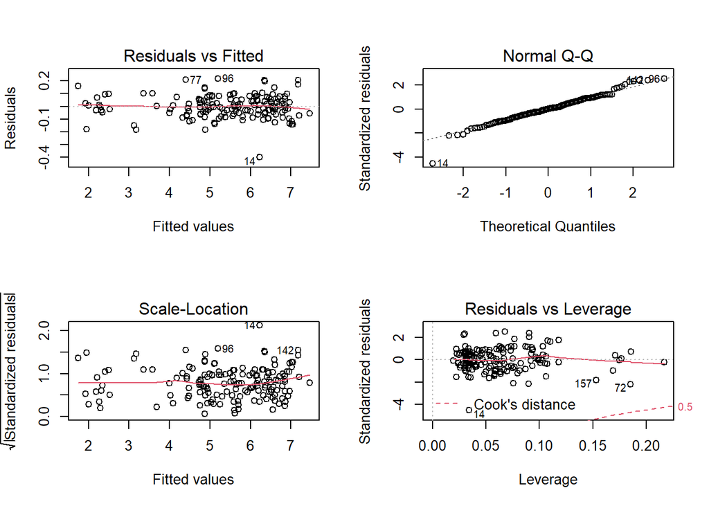

#### **Independent data**

From given data description, each observation of different fishes is from fish market sales.Here we assume that all the data are independent.

#### **Normality of residuals**

Normality of residuals are almost satisfied except for few observations are placed out of the linear line.

##### **Consequently, although there are some observations which disturb the assumption of the model, the model approximately satisfies the assumption.**

**(e)**

> Check if there are outliers or influential observations.

The leverage is measurements of the potential influence to model parameters if a data point be shifted with a unit in the y-direction and measurements of the distance of the predictor values of the i-th observation in the sample to the mean predictor values in the sample. The leverage varies between 1/n and 1 and has a mean of p/n for all the observations. Leverages larger than 2p/n are considered extreme

```r
p <- length(coef(finalmodel))   # the number of parameters
n <- nrow(fish)                # the number of observations
df <- n-p
leverageTreshold <- (2*p) / n
lev = hat(model.matrix(finalmodel))
which( lev >leverageTreshold)
```

```
## [1]  55  56  57  58  59  60  72 157
```

To find extreme residuals,we have to find value more than $1.96*\hat{\sigma}$.

```r
which(abs(resid(finalmodel)) > 1.959964 * summary(finalmodel)$sigma)
```

```
##  14  17  18  72  77  90  96 142 158
##  14  17  18  72  77  90  96 142 158
```

14,17,18,72,77,90,96,142,158 extreme residuals

if Cook’s distance is over the 50% percentile of an $F_{p,n-p}$-distribution, it is extreme Cook’s distance

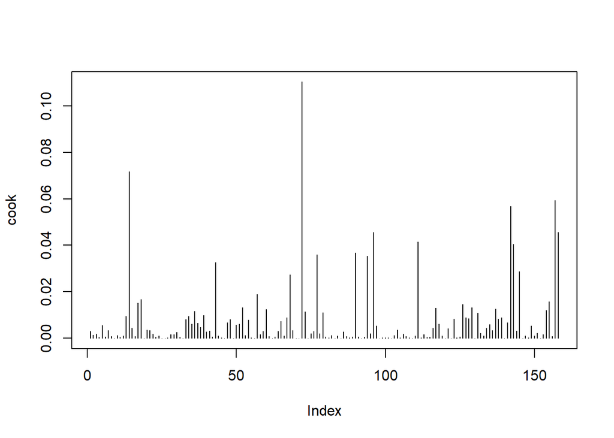

```r
cook <- cooks.distance(finalmodel)
plot(cook,type='h')
```

```r
fquantile <- qf(0.5,df1 = p,df2 = n - p)
cook < fquantile
```

[output not shown]

```r
which(cook > fquantile)
```

```
## named integer(0)
```

**Fortunately, there is no extreme observations in this model base on the Cook’s distance. also, Cook’s distance well distributed under approximately 0.1**

we have to conduct DFBETA’s to find extreme influence coefficient. a value for DFBETAS is consider to be extreme influence if it surpasses $\frac{2}{\sqrt{n}}$ for large datasets. for small and moderate sized datasets, a value is considered to be extreme if it surpasses 1. our datasets can be considered to large datasets

```r
dfb <- dfbetas(finalmodel)
dfb > 2 / sqrt(n)
```

[output not shown]

[output cut: 462 more lines]

```r
which(rowSums(dfb > 2 / sqrt(n))!=0)
```

```
##  14  43  52  65  67  68  72  77  79  90  94  96 111 117 123 129 137 142 143 155
##  14  43  52  65  67  68  72  77  79  90  94  96 111 117 123 129 137 142 143 155
## 157
## 157
```

### **Results**

> Describe the results as if you would write the results section of a paper.

#### **All the successive models**

##### **model3 <- lm(Weightslog ~ Widthlog + Heightlog + Length2log)**

##### **finalmodel <- lm(Weightslog ~ Widthlog + Heightlog + Length2log + factor(Species))**

our final model has 158 observations, and dependent variable is Weightslog[-41]. it has results shown below.

$F(9,148) = 3766.25, p = 0.00$  
$R² = 1.00$  
$Adj. R² = 1.00$

```r
summ(finalmodel)
```

| Observations | 158 |
| --- | --- |
| Dependent variable | Weightslog[-41] |
| Type | OLS linear regression |

| F(9,148) | 3766.25 |
| --- | --- |
| R² | 1.00 |
| Adj. R² | 1.00 |

|  | Est. | S.E. | t val. | p |
| --- | --- | --- | --- | --- |
| (Intercept) | -2.54 | 0.25 | -10.30 | 0.00 |
| Widthlog[-41] | 0.55 | 0.12 | 4.74 | 0.00 |
| Heightlog[-41] | 0.73 | 0.15 | 4.83 | 0.00 |
| Length2log[-41] | 1.72 | 0.16 | 11.03 | 0.00 |
| factor(Species[-41])Parkki | 0.08 | 0.03 | 2.36 | 0.02 |
| factor(Species[-41])Perch | 0.11 | 0.08 | 1.37 | 0.17 |
| factor(Species[-41])Pike | 0.03 | 0.14 | 0.24 | 0.81 |
| factor(Species[-41])Roach | 0.09 | 0.07 | 1.38 | 0.17 |
| factor(Species[-41])Smelt | -0.07 | 0.12 | -0.54 | 0.59 |
| factor(Species[-41])Whitefish | 0.19 | 0.07 | 2.65 | 0.01 |

Standard errors: OLS

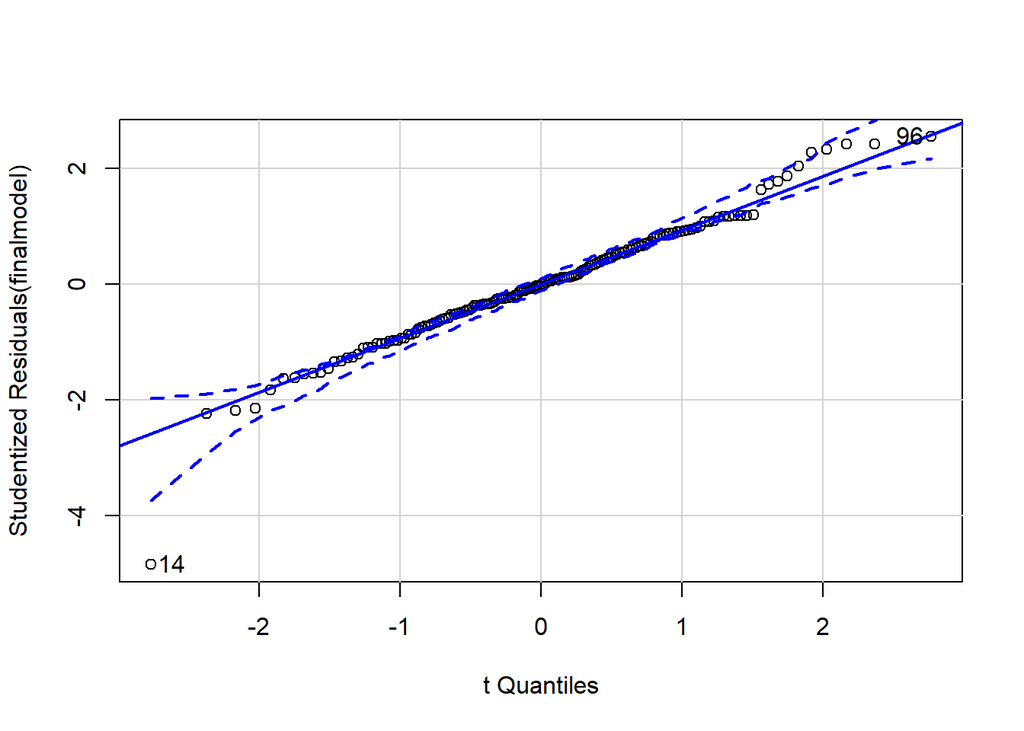

```
## [1] 14 96
```

```r
qqPlot(finalmodel)
```

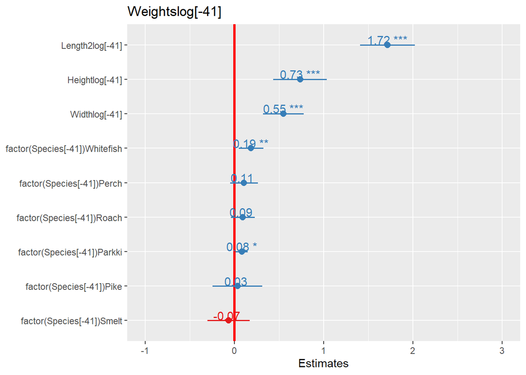

```r
plot_model(finalmodel, vline.color = "red", show.values = TRUE, sort.est = TRUE)
```

> Create a table containing an overview of the selected regression coefficients in each of the successive models, including their t-value and p-value.

tab_model() function was used to make a table that shows the t-value and p-value of each predictors for different models. In order to use tab_model() function, three packages have to be called which are sjPlot, sjmisc, and sjlabelled. By altering different parameters in the tab_model() function, table name, row name, and column name were defined. Also, only preferred values were selected to show in the table.

```r
tab_model(title = "Table 1: Comparsion of t-value and p-value between the successive models. (Note: All the predictors are in log form)", model1, model2, model3, finalmodel, pred.labels = c("(Intercept)", "Width", "Height", "Length2", "Parkki", "Perch", "Pike", "Roach", "Smelt", "Whitefish"), dv.labels = c("Model 1", "Model 2", "Model 3", "Final model"), show.stat = TRUE, show.ci = FALSE, show.est = TRUE, string.stat = "t-value",  string.p = "p-value")
```

Table 1: Comparsion of t-value and p-value between the successive models. (Note: All the predictors are in log form)

|  | Model 1 |  |  | Model 2 |  |  | Model 3 |  |  | Final model |  |  |
| --- | --- | --- | --- | --- | --- | --- | --- | --- | --- | --- | --- | --- |
| Predictors | Estimates | t-value | p-value | Estimates | t-value | p-value | Estimates | t-value | p-value | Estimates | t-value | p-value |
| (Intercept) | 1.54 | 23.26 | **<0.001** | 1.30 | 17.50 | **<0.001** | -2.01 | -16.51 | **<0.001** | -2.54 | -10.30 | **<0.001** |
| Width | 2.77 | 61.46 | **<0.001** | 2.28 | 24.02 | **<0.001** | 0.90 | 14.44 | **<0.001** | 0.55 | 4.74 | **<0.001** |
| Height |  |  |  | 0.45 | 5.74 | **<0.001** | 0.61 | 18.83 | **<0.001** | 0.73 | 4.83 | **<0.001** |
| Length2 |  |  |  |  |  |  | 1.50 | 28.03 | **<0.001** | 1.72 | 11.03 | **<0.001** |
| Parkki |  |  |  |  |  |  |  |  |  | 0.08 | 2.36 | **0.019** |
| Perch |  |  |  |  |  |  |  |  |  | 0.11 | 1.37 | 0.173 |
| Pike |  |  |  |  |  |  |  |  |  | 0.03 | 0.24 | 0.812 |
| Roach |  |  |  |  |  |  |  |  |  | 0.09 | 1.38 | 0.169 |
| Smelt |  |  |  |  |  |  |  |  |  | -0.07 | -0.54 | 0.588 |
| Whitefish |  |  |  |  |  |  |  |  |  | 0.19 | 2.65 | **0.009** |
| Observations | 158 |  |  | 158 |  |  | 158 |  |  | 158 |  |  |
| R<sup>2</sup> / R<sup>2</sup> adjusted | 0.960 / 0.960 |  |  | 0.967 / 0.967 |  |  | 0.995 / 0.995 |  |  | 0.996 / 0.995 |  |  |

Describe model Table 1 shows a summary of all the regression coefficients for the preferred models. It also shows the t-values and p-values for each multivariate predictors within the model.

The model was constructed exhaustively with a forward model approach, which starts from the empty model and the new predictors were added based on its largest t-value, with their p-values being less than 0.05. This is to verify if certain predictors in the model were significantly associated with the outcome.

> Create a table for the successive models. Include, for each model, the $R^2$-value and Residual Sum of Errors (RSE).

To create a table comparing R2 and RSE values for different models, kable() function was used. In order to use kable() function, it requires knitr and kableExtra packages. A table containing all the information (name of the model, R2 for each successive models, and RSE for each successive models) was created beforehand, and using kable() function, created-table is decorated.

```r
# Making a table comparing models with R-squared value and Residual Sum of Errors (RSE).
allmodel_name <- c("Width", "Width + Height", "Width + Height + Length2", "Width + Height + Length2 + Species factor")

allmodel_r_squared <- c(summary(model1)$r.squared, summary(model2)$r.squared, summary(model3)$r.squared, summary(finalmodel)$r.squared)

allmodel_RSE <- c(sum(residuals(model1)^2), sum(residuals(model2)^2),sum(residuals(model3)^2), sum(residuals(finalmodel)^2))

table3 <- data.frame("Model" = allmodel_name, "R-squared" = allmodel_r_squared, "RSE" = allmodel_RSE)

library(knitr)
library(kableExtra)

kable(table3, align = c('l', 'c', 'c'), caption = "Table 2: Comparison of R-squared values and RSE for the successive models") %>%
  kable_styling(bootstrap_options = c("striped", "hover", "condensed"), full_width = T) %>%
  footnote(general = "All the predictors are tranformed in logarithmic form.")
```

Table 2: Comparison of R-squared values and RSE for the successive models

| Model | R.squared | RSE |
| --- | --- | --- |
| Width | 0.9603424 | 10.950197 |
| Width + Height | 0.9672893 | 9.032035 |
| Width + Height + Length2 | 0.9946394 | 1.480166 |
| Width + Height + Length2 + Species factor | 0.9956527 | 1.200364 |

> Include a figure inspecting the relation between the predicted and measured weight values.

Different Species are represented by different colors:

The red dots represent Bream.

The orange dots represent Roach.

The yellow dots represent Whitefish.

The green dots represent Parkki.

The blue dots represent Perch.

The navy dots represent Pike.

The purple dots represent Smelt.

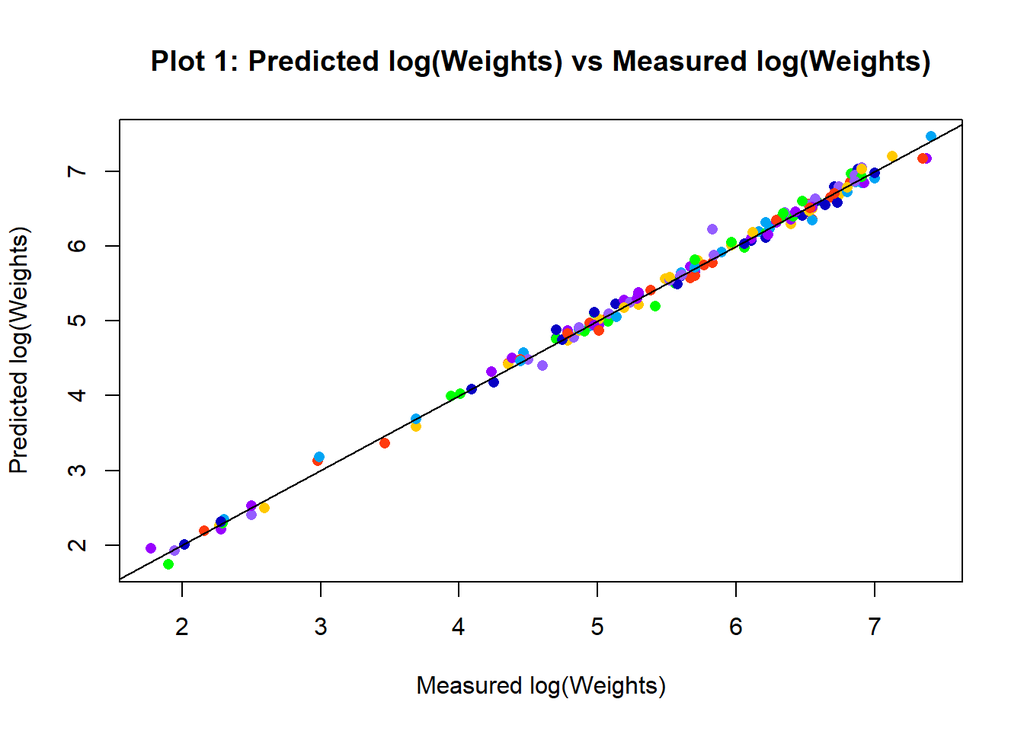

```r
plot(Weightslog[-41], predict(finalmodel),col= my_cols, pch =16, main =  "Plot 1: Predicted log(Weights) vs Measured log(Weights)", xlab = "Measured log(Weights)", ylab = "Predicted log(Weights)")
abline(a=0,b=1)
```